# Peptide identification Quick summary

Suggestions to imetalabca@gmail.com

Report generated @2022-02-25 15:59:58

# 1 Intro

**This report provides some basic description of the peptide identificaiton from database search.** **Users can use this to quickly check the overal quality of the experiment** **Users can download the clean peptide quantification matrix for downstream analysis**

# 2 Take-home figures

- **Number of contaminant:** 0
- **Number of reversed:** 0
- **Number of qualified peptides:** 21468
- **Number of quailfied peptide without intensity information(0 intensitiy):** 844
- **Number of experiment:** 6
- **All experiments:** DMSO1, DMSO2, DMSO3, Diclofenac1, Diclofenac2, Diclofenac3
- **Groups:** , DMSO, DCLF

# 3 Peptide Charge States

**Why charge state?**

1. Peptide Charge distribution is a good sign of trypsin digestion and electric spray ionization.
- In a typical ESI analysis of trytic digest, most of the peptides should have 2 charges, less peptides have 3 charges, because tryptic peptides have a lysine/arginie at the C-terminal, along with N-terminal contributing another charge. A possible miscleavage will contribute the third charge.
- In a ESI procedure, peptides with 2 and more charges are easier to fragment and then identified by MS. However, too mnay charges will make the m/z of the peptide too small to escape the scan range, further more, it will also complicate the ms2 spectra.
2. if you see more peptides with charge 3 than charge 2 state,
- It might indcate in-sufficient trypsin digesion, check the percentage of peptides with mis-cleavage site.
- It migtht indcate the ESI is not sufficient/good enough.Check the distance between the ESI tip and MS oriface, if the ESI tip is dirty, if there is droplet occasionally.

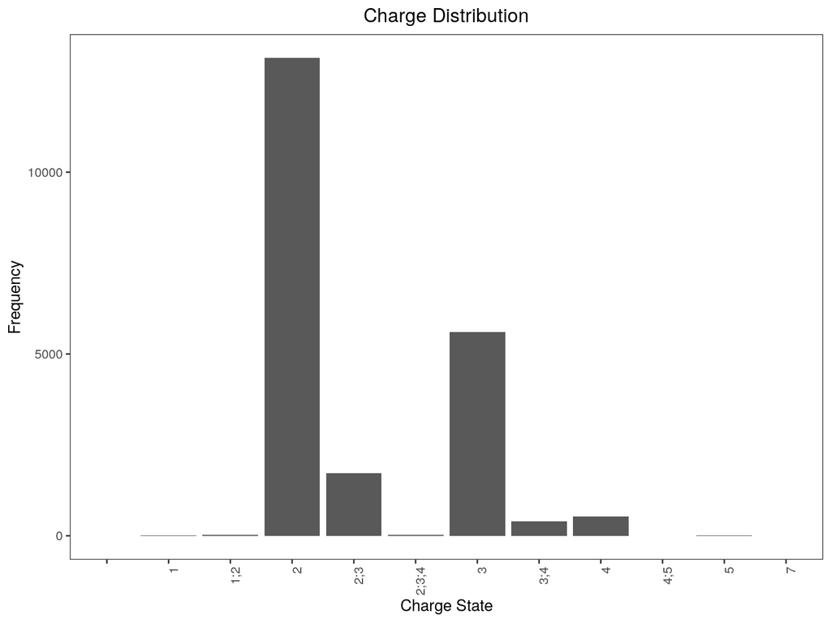

# 4 Peptide Length

**Why peptide length do you expect?**

- Averge length of tryptic peptide is around 10.
- refer to this page for peptide length.

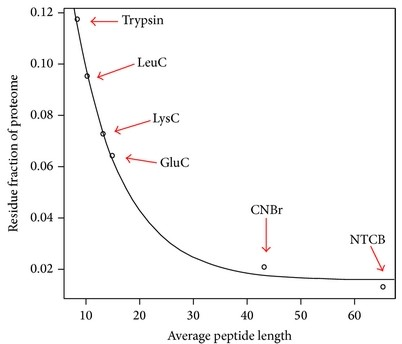

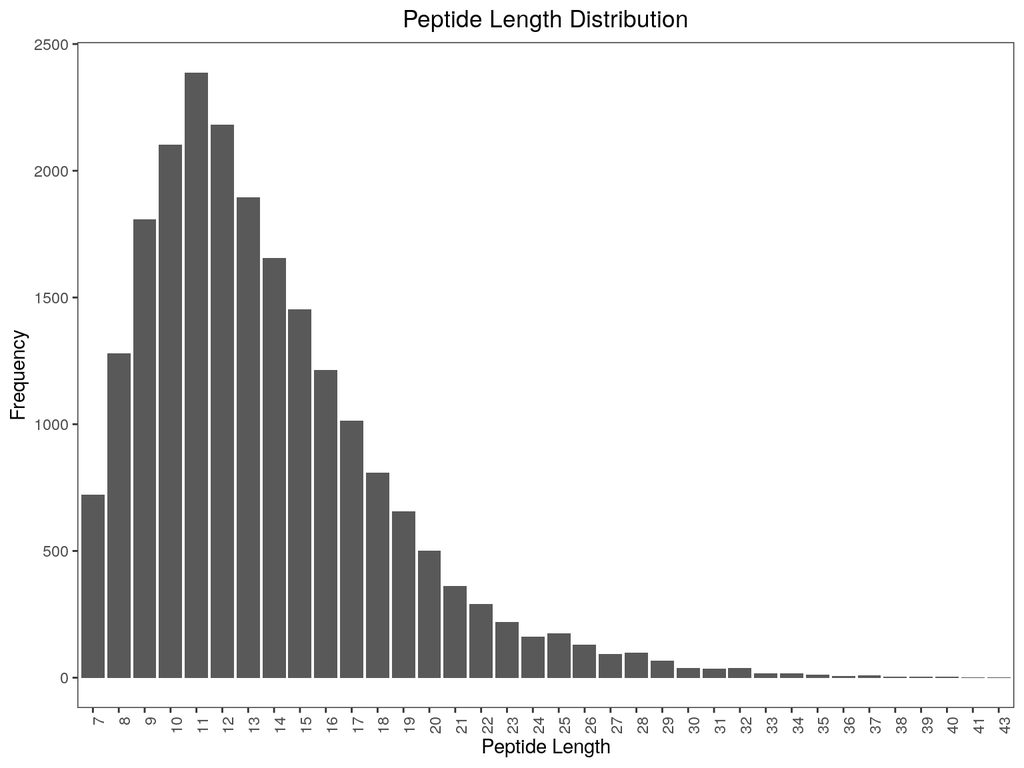

# 5 Peptide Score distribution

- The average score should be around 50

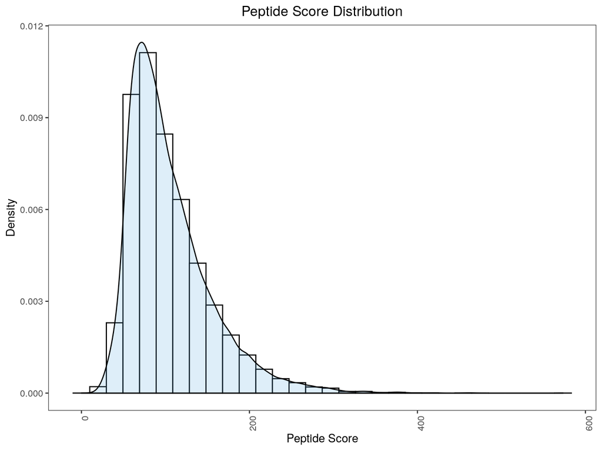

# 6 Quantification Sparsity Distrubition

In most cases, label-free quantification provides a decent way for metaproteomics profiling.

## 6.1 Sparsity Profile

**The more peptide of 100% presence the better**

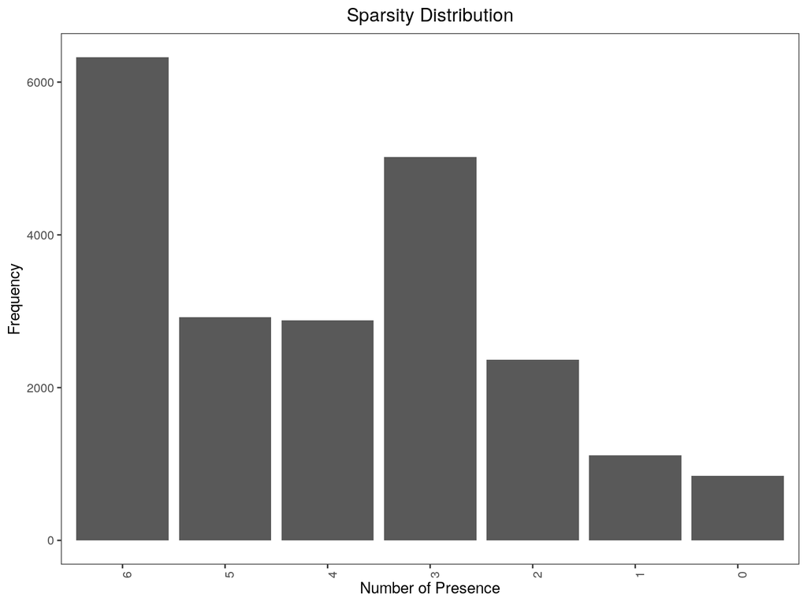

## 6.2 Sparsity cummulative curve

Figure shows how many peptides have more than N presence, which helps to set the presence cutoff

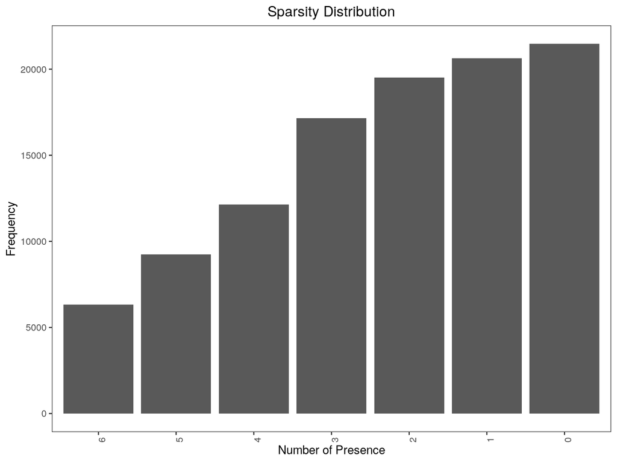

# 7 Peptide Intensity disitribution across samples/experiments

[figure not shown]

# 8 Overall Expression Profile

## 8.1 Heatmap

### 8.1.1 Heatmap of Q100 peptides (with 100% presence across experiments)

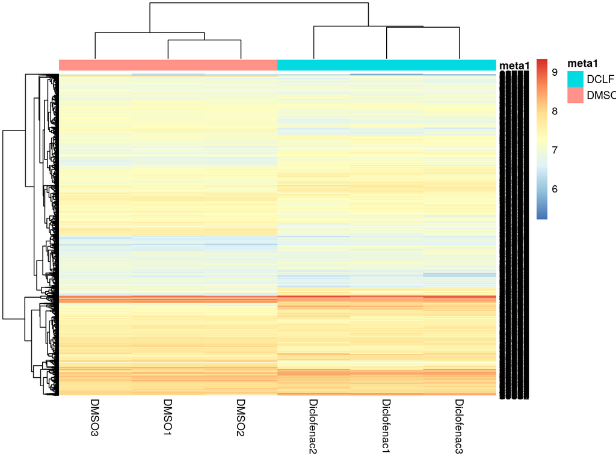

### 8.1.2 Heatmap of Top 100 Intensity peptides

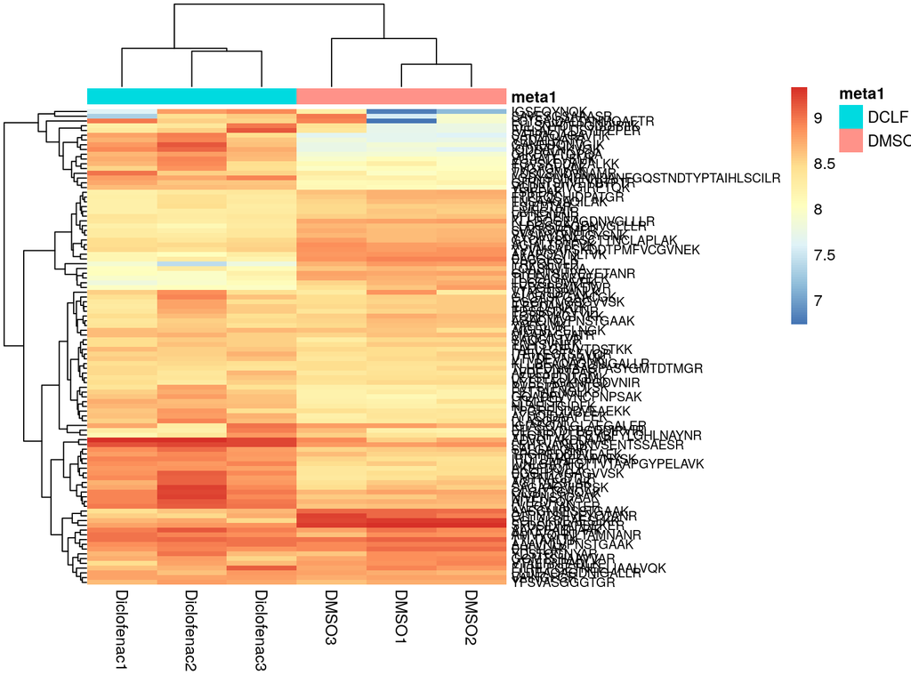

# 9 PCA Analysis

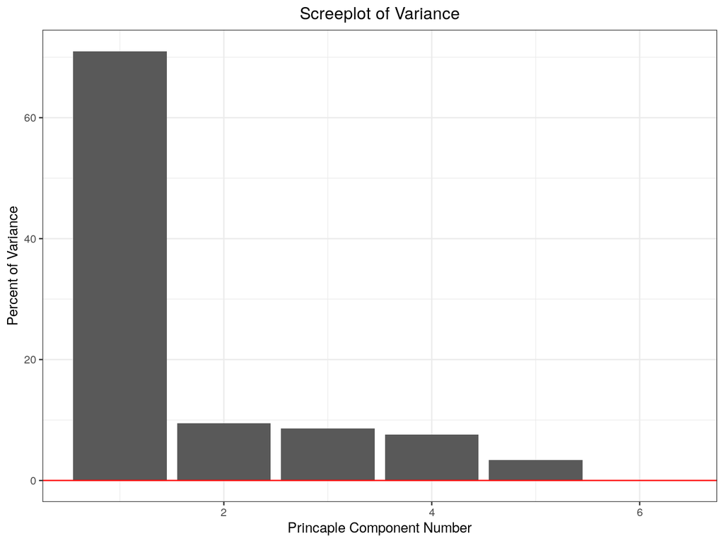

```
## Scree plot ##  shows the performance of the PCA analysis, the more percentage the top procomponets accounts, the better separation
```

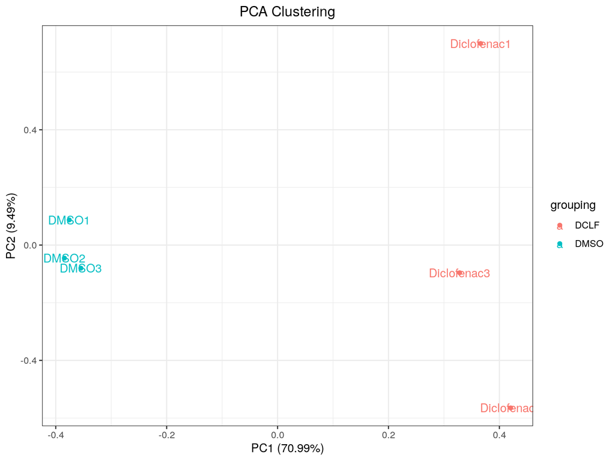

```
## 2d PCA Component plot ##
```

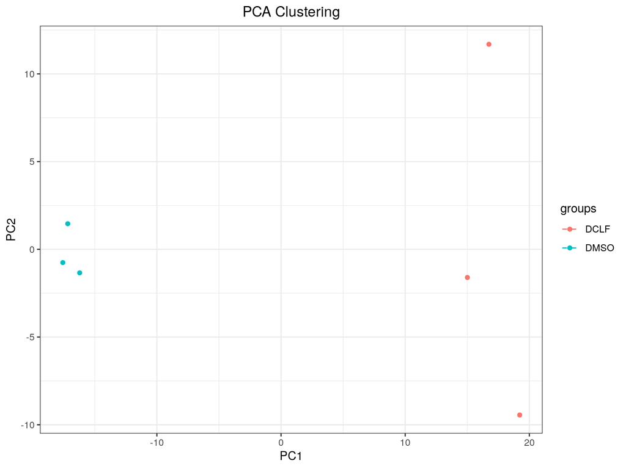

[output not shown]

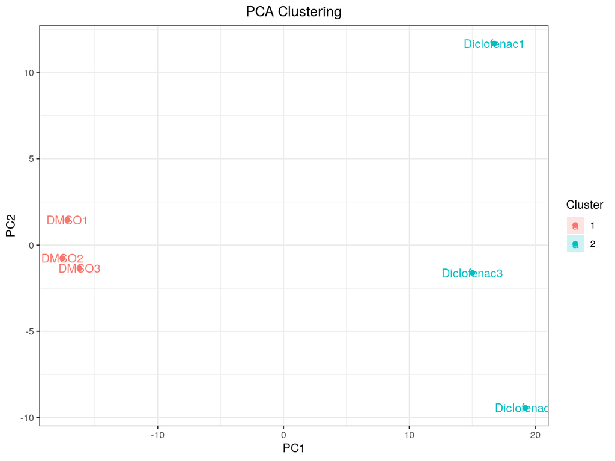

```
## 2d PCA Component plot with K-means grouping, which is non-supervised grouping
```